# 320 Final Project

Part 1 Data collection

This code reads the locally stored CSV file, then shows the first few rows of output in order to show what the downloaded data looks like unmodified.

```r
library(tidyverse)
library(naniar)
library(ggplot2)

# CSV file downloaded at "https://www.kaggle.com/justinas/nba-players-data"
nba_tab <- read_csv("all_seasons.csv")
head(nba_tab)
```

| NO | player_name | team_abbreviation | age | player_height | player_weight | college | country | draft_year | draft_round | draft_number | gp | pts | reb | ast | net_rating | oreb_pct | dreb_pct | usg_pct | ts_pct | ast_pct | season |
| --- | --- | --- | --- | --- | --- | --- | --- | --- | --- | --- | --- | --- | --- | --- | --- | --- | --- | --- | --- | --- | --- |
| 0 | Dennis Rodman | CHI | 36 | 198.12 | 99.79024 | Southeastern Oklahoma State | USA | 1986 | 2 | 27 | 55 | 5.7 | 16.1 | 3.1 | 16.1 | 0.186 | 0.323 | 0.100 | 0.479 | 0.113 | 1996-97 |
| 1 | Dwayne Schintzius | LAC | 28 | 215.90 | 117.93392 | Florida | USA | 1990 | 1 | 24 | 15 | 2.3 | 1.5 | 0.3 | 12.3 | 0.078 | 0.151 | 0.175 | 0.430 | 0.048 | 1996-97 |
| 2 | Earl Cureton | TOR | 39 | 205.74 | 95.25432 | Detroit Mercy | USA | 1979 | 3 | 58 | 9 | 0.8 | 1.0 | 0.4 | -2.1 | 0.105 | 0.102 | 0.103 | 0.376 | 0.148 | 1996-97 |
| 3 | Ed O'Bannon | DAL | 24 | 203.20 | 100.69742 | UCLA | USA | 1995 | 1 | 9 | 64 | 3.7 | 2.3 | 0.6 | -8.7 | 0.060 | 0.149 | 0.167 | 0.399 | 0.077 | 1996-97 |
| 4 | Ed Pinckney | MIA | 34 | 205.74 | 108.86208 | Villanova | USA | 1985 | 1 | 10 | 27 | 2.4 | 2.4 | 0.2 | -11.2 | 0.109 | 0.179 | 0.127 | 0.611 | 0.040 | 1996-97 |
| 5 | Eddie Johnson | HOU | 38 | 200.66 | 97.52228 | Illinois | USA | 1981 | 2 | 29 | 52 | 8.2 | 2.7 | 1.0 | 4.1 | 0.034 | 0.126 | 0.220 | 0.541 | 0.102 | 1996-97 |

Part 2 Data Processing

## Data Management:

# cleaning data

[Should we convert draft_year and season columns into integers/dates? (lubridate). There might not be a point for some of them]

After loading the data, we now create a tidier data table with some characteristics changed in order to set it up for analysis later. We create a new column called ‘undrafted’ that is true if that player was undrafted, and false if not. We then replace entries that had “undrafted” listed as their draft_year, draft_round, and draft_number with ‘NA’ instead. We convert the draft_round, draft_year, and draft_number columns to be integers instead of characters. Additionally, since the NBA switched to a 2-round draft in 1989, to accurately measure the value of draft picks in the modern draft format, we’re going to filter out any players who were drafted before 1989. We also exclude erroneous entries that have draft_round listed as greater than 2.

```r
tidy_nba <-
  nba_tab %>%
mutate(Undrafted = ifelse(draft_round == "Undrafted" | draft_year == "Undrafted" |
                        draft_number == "Undrafted",TRUE,FALSE)) %>%
  replace_with_na_all(condition = ~.x == "Undrafted")

tidy_nba$draft_round <- as.integer(tidy_nba$draft_round)
tidy_nba$draft_year <- as.integer(tidy_nba$draft_year)
tidy_nba$draft_number <- as.integer(tidy_nba$draft_number)

tidy_nba <-
  filter(tidy_nba, (draft_year >= 1989 | is.na(draft_year)) &
        (draft_round <= 2 | is.na(draft_round)))

head(tidy_nba)
```

| NO | player_name | team_abbreviation | age | player_height | player_weight | college | country | draft_year | draft_round | draft_number | gp | pts | reb | ast | net_rating | oreb_pct | dreb_pct | usg_pct | ts_pct | ast_pct | season | Undrafted |
| --- | --- | --- | --- | --- | --- | --- | --- | --- | --- | --- | --- | --- | --- | --- | --- | --- | --- | --- | --- | --- | --- | --- |
| 1 | Dwayne Schintzius | LAC | 28 | 215.90 | 117.93392 | Florida | USA | 1990 | 1 | 24 | 15 | 2.3 | 1.5 | 0.3 | 12.3 | 0.078 | 0.151 | 0.175 | 0.430 | 0.048 | 1996-97 | FALSE |
| 3 | Ed O'Bannon | DAL | 24 | 203.20 | 100.69742 | UCLA | USA | 1995 | 1 | 9 | 64 | 3.7 | 2.3 | 0.6 | -8.7 | 0.060 | 0.149 | 0.167 | 0.399 | 0.077 | 1996-97 | FALSE |
| 6 | Eddie Jones | LAL | 25 | 198.12 | 86.18248 | Temple | USA | 1994 | 1 | 10 | 80 | 17.2 | 4.1 | 3.4 | 4.1 | 0.035 | 0.091 | 0.209 | 0.559 | 0.149 | 1996-97 | FALSE |
| 7 | Elden Campbell | LAL | 28 | 213.36 | 113.39800 | Clemson | USA | 1990 | 1 | 27 | 77 | 14.9 | 8.0 | 1.6 | 3.3 | 0.095 | 0.183 | 0.222 | 0.520 | 0.087 | 1996-97 | FALSE |
| 8 | Eldridge Recasner | ATL | 29 | 193.04 | 86.18248 | Washington | USA | 1992 | NA | NA | 71 | 5.7 | 1.6 | 1.3 | -0.3 | 0.036 | 0.076 | 0.172 | 0.539 | 0.141 | 1996-97 | TRUE |
| 9 | Elliot Perry | MIL | 28 | 182.88 | 72.57472 | Memphis | USA | 1991 | 2 | 37 | 82 | 6.9 | 1.5 | 3.0 | -1.2 | 0.018 | 0.081 | 0.177 | 0.557 | 0.262 | 1996-97 | FALSE |

This code creates a dataframe that only includes players in their rookie seasons. The first season this dataset has data from is the 1996-1997 season. Some players who played in the 1996 had been drafted before that year, and because undrafted players do not have a draft_year listed and so it cannot be determined whether 1996 was their first season or not, we’re only looking at all rookie seasons starting from 1997 instead.

```r
# distinct() removes all duplicates based on the player_name variable if there's
# already another row with that value. The tidy_nba is sorted by season, so it'll
# remove all seasons besides their first season for all players.
rookie_after_1997_df <-
  tidy_nba %>%
  distinct(player_name, .keep_all = TRUE) %>%
  filter(season != "1996-97")

rookie_after_1997_df
```

| NO | player_name | team_abbreviation | age | player_height | player_weight | college | country | draft_year | draft_round | draft_number | gp | pts | reb | ast | net_rating | oreb_pct | dreb_pct | usg_pct | ts_pct | ast_pct | season | Undrafted |
| --- | --- | --- | --- | --- | --- | --- | --- | --- | --- | --- | --- | --- | --- | --- | --- | --- | --- | --- | --- | --- | --- | --- |
| 442 | Marko Milic | PHX | 21 | 198.12 | 106.59412 | None | Slovenia | 1997 | 2 | 33 | 33 | 2.8 | 0.8 | 0.4 | 7.4 | 0.076 | 0.099 | 0.245 | 0.644 | 0.113 | 1997-98 | FALSE |
| 448 | Maurice Taylor | LAC | 21 | 205.74 | 117.93392 | Michigan | USA | 1997 | 1 | 14 | 71 | 11.5 | 4.2 | 0.7 | -9.5 | 0.089 | 0.136 | 0.262 | 0.521 | 0.069 | 1997-98 | FALSE |
| 458 | Mario Bennett | LAL | 24 | 205.74 | 106.59412 | Arizona State | USA | 1995 | 1 | 27 | 45 | 3.9 | 2.8 | 0.4 | 5.0 | 0.164 | 0.207 | 0.201 | 0.573 | 0.084 | 1997-98 | FALSE |
| 464 | Mark Pope | IND | 25 | 208.28 | 106.59412 | Kentucky | USA | 1996 | 2 | 52 | 28 | 1.4 | 0.9 | 0.3 | -0.2 | 0.056 | 0.115 | 0.145 | 0.402 | 0.062 | 1997-98 | FALSE |
| 489 | Michael Stewart | SAC | 23 | 208.28 | 104.32616 | California | USA | NA | NA | NA | 81 | 4.6 | 6.6 | 0.8 | -3.0 | 0.125 | 0.211 | 0.120 | 0.486 | 0.054 | 1997-98 | TRUE |
| 491 | Michael McDonald | CHH | 29 | 208.28 | 105.23334 | New Orleans | USA | 1995 | 2 | 55 | 1 | 0.0 | 1.0 | 0.0 | -71.4 | 0.250 | 0.000 | 0.250 | 0.000 | 0.000 | 1997-98 | FALSE |
| 497 | Kebu Stewart | PHI | 24 | 203.20 | 108.40849 | Cal State-Bakersfield | USA | 1997 | 2 | 35 | 15 | 2.7 | 2.1 | 0.1 | 11.7 | 0.087 | 0.212 | 0.173 | 0.541 | 0.030 | 1997-98 | FALSE |
| 502 | Johnny Taylor | ORL | 24 | 205.74 | 99.79024 | Tennessee-Chattanooga | USA | 1997 | 1 | 17 | 12 | 3.2 | 1.1 | 0.1 | 4.8 | 0.043 | 0.127 | 0.215 | 0.431 | 0.014 | 1997-98 | FALSE |
| 505 | John Thomas | TOR | 22 | 205.74 | 120.20188 | Minnesota | USA | 1997 | 1 | 25 | 54 | 2.8 | 2.0 | 0.3 | -2.6 | 0.099 | 0.133 | 0.145 | 0.552 | 0.050 | 1997-98 | FALSE |
| 519 | Keith Booth | CHI | 23 | 198.12 | 102.51179 | Maryland | USA | 1997 | 1 | 28 | 6 | 1.7 | 0.7 | 0.2 | -10.0 | 0.100 | 0.125 | 0.236 | 0.579 | 0.077 | 1997-98 | FALSE |

[output cut: 990 more lines]

Part 3 Exploratory Data Analysis and Visualization

[could possibly use this rookie data frame to create a new boolean column ‘rookie’ that indicates if it’s a players first season or not]

group_by season, group_by draft pick?

Grouping all the rookie seasons by their draft pick to show the averages for all playing statistics (games played, points, etc.) by players chosen with that pick in their rookie season.

```r
rookie_performance_by_pick_df <-
rookie_after_1997_df %>%
  group_by(draft_number) %>%
  summarize_at(vars(gp:ast_pct), list(mean = mean))

rookie_performance_by_pick_df
```

| draft_number | gp_mean | pts_mean | reb_mean | ast_mean | net_rating_mean | oreb_pct_mean | dreb_pct_mean | usg_pct_mean | ts_pct_mean | ast_pct_mean |
| --- | --- | --- | --- | --- | --- | --- | --- | --- | --- | --- |
| 1 | 66.56522 | 14.469565 | 7.008696 | 2.8347826 | -2.2260870 | 0.08065217 | 0.1834783 | 0.2255652 | 0.5313478 | 0.14934783 |
| 2 | 67.43478 | 11.265217 | 4.800000 | 2.4826087 | -5.3173913 | 0.06147826 | 0.1519565 | 0.2103043 | 0.5060435 | 0.13813043 |
| 3 | 68.86957 | 12.247826 | 4.795652 | 2.1347826 | -3.1130435 | 0.05869565 | 0.1471304 | 0.2189565 | 0.5228261 | 0.13552174 |
| 4 | 65.78261 | 10.769565 | 4.604348 | 2.3956522 | -5.7086957 | 0.06108696 | 0.1453043 | 0.2097826 | 0.5028261 | 0.13886957 |
| 5 | 69.50000 | 9.312500 | 3.875000 | 2.5208333 | -4.3458333 | 0.05791667 | 0.1376667 | 0.1999583 | 0.4934583 | 0.15187500 |
| 6 | 64.43478 | 9.421739 | 3.943478 | 1.8956522 | -4.7826087 | 0.05639130 | 0.1284783 | 0.1807826 | 0.5192174 | 0.10943478 |
| 7 | 68.65217 | 10.508696 | 4.260870 | 2.2478261 | -7.8956522 | 0.04886957 | 0.1316087 | 0.1988261 | 0.5015652 | 0.12469565 |
| 8 | 61.00000 | 6.837500 | 2.916667 | 1.5708333 | -3.8291667 | 0.05712500 | 0.1285000 | 0.1861667 | 0.4866667 | 0.11883333 |
| 9 | 58.08696 | 8.095652 | 3.973913 | 1.5956522 | -3.6652174 | 0.07230435 | 0.1561739 | 0.1904348 | 0.5112609 | 0.11095652 |
| 10 | 63.95652 | 7.913043 | 3.286957 | 1.8608696 | -5.0826087 | 0.04973913 | 0.1293913 | 0.1930000 | 0.4947826 | 0.12865217 |

[output cut: 51 more lines]

I want to show the relationship between the number of drafts with average points of players. First, I remove the NA(undrafted) player from the list and use linear regression to find the correlationship. By using linear regression, it is clearly in the graph that the number of drafts has a negative relationship with average points, which means that the player with lower draft numbers seems to play better than the player with high draft numbers.

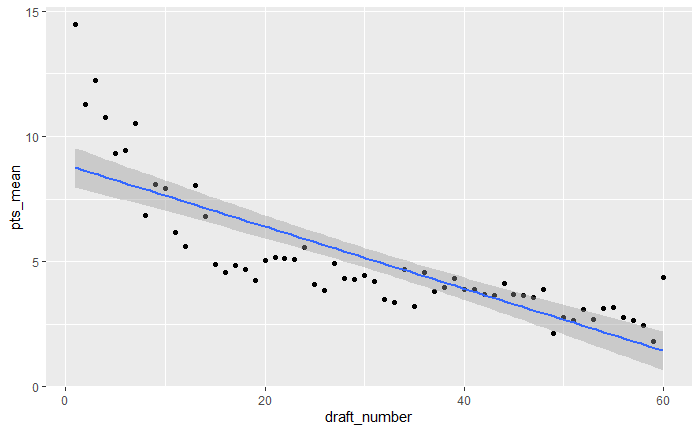

```r
rookie_performance_by_pick_df<-na.omit(rookie_performance_by_pick_df)
rookie_performance_by_pick_df%>%ggplot(aes(x=draft_number,y=pts_mean))+geom_point()+geom_smooth(method=lm)
```

[potential ideas: Make scatter plot of every rookie season with draft number on one axis and pts or gp or something else on the other? For every draft pick, there’s only about 20 points of data. Could partition it by draft round or by every 10 picks or so instead to get more data points? (so grouped by picks 1-10, 11-20, etc.)]

[make boxplot or violin plot or something grouped by round or a range of picks to try and show the deviation and try to measure how many players picked in that range pan out?]

[thinking about how to represent undrafted players, include them all as a single X value?] Scatter plots of draft number vs rating, gp, pts, and shot pct

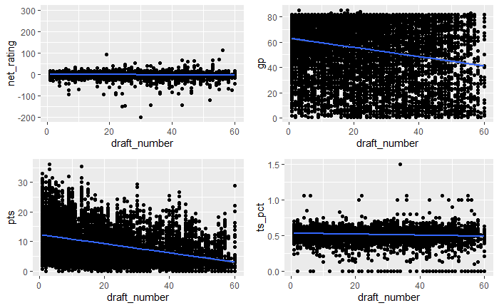

```r
library(gridExtra)
p1 <- tidy_nba %>%
  ggplot(aes(x=draft_number, y=net_rating)) +
  geom_point()+geom_smooth(method=lm)
p2 <- tidy_nba %>%
  ggplot(aes(x=draft_number, y=gp)) +
  geom_point()+geom_smooth(method=lm)
p3 <- tidy_nba %>%
  ggplot(aes(x=draft_number, y=pts)) +
  geom_point()+geom_smooth(method=lm)
p4 <- tidy_nba %>%
  ggplot(aes(x=draft_number, y=ts_pct)) +
  geom_point()+geom_smooth(method=lm)
grid.arrange(p1,p2,p3,p4, nrow = 2)
```

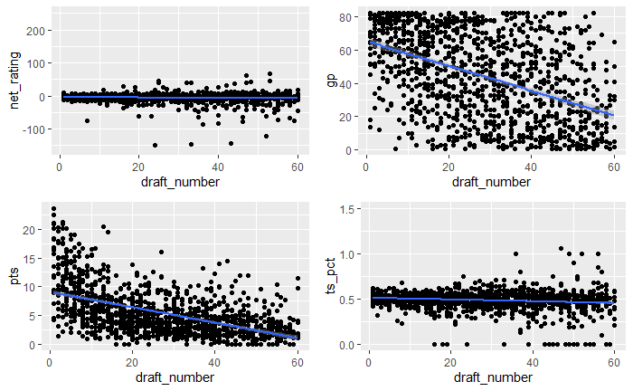

```r
p1 <- rookie_after_1997_df %>%
  ggplot(aes(x=draft_number, y=net_rating)) +
  geom_point()+geom_smooth(method=lm)
p2 <- rookie_after_1997_df %>%
  ggplot(aes(x=draft_number, y=gp)) +
  geom_point()+geom_smooth(method=lm)
p3 <- rookie_after_1997_df %>%
  ggplot(aes(x=draft_number, y=pts)) +
  geom_point()+geom_smooth(method=lm)
p4 <- rookie_after_1997_df %>%
  ggplot(aes(x=draft_number, y=ts_pct)) +
  geom_point()+geom_smooth(method=lm)
grid.arrange(p1, p2,p3,p4, nrow = 2)
```

Density plots comparing drafted to undrafted players, not much difference in shape of distributions except in games played.

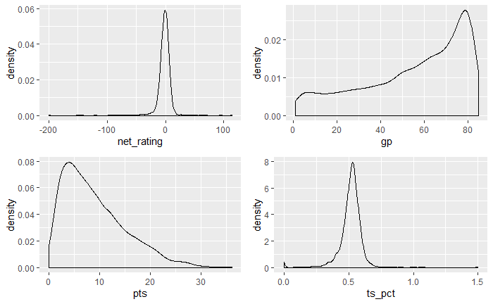

```r
undrafted_df <- tidy_nba %>%
  filter(is.na(draft_number))
drafted_df <- tidy_nba %>%
  na.omit()

p1 <- drafted_df %>%
  ggplot(aes(x=net_rating)) +
  geom_density()
p2 <- drafted_df %>%
  ggplot(aes(x=gp)) +
  geom_density()
p3 <- drafted_df %>%
  ggplot(aes(x=pts)) +
  geom_density()
p4 <- drafted_df %>%
  ggplot(aes(x=ts_pct)) +
  geom_density()
grid.arrange(p1, p2,p3,p4, nrow = 2)
```

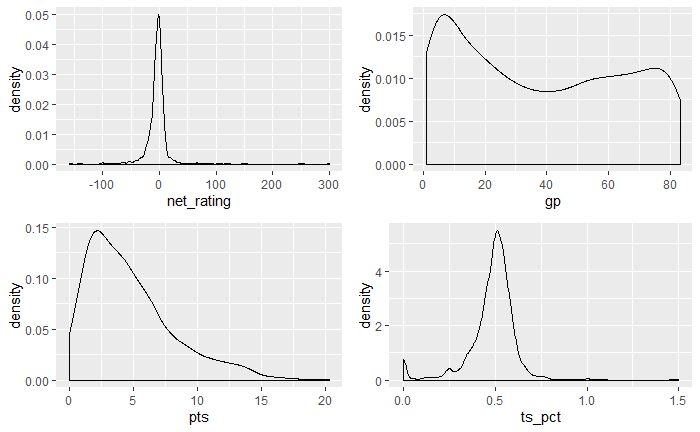

```r
p1 <- undrafted_df %>%
  ggplot(aes(x=net_rating)) +
  geom_density()
p2 <- undrafted_df %>%
  ggplot(aes(x=gp)) +
  geom_density()
p3 <- undrafted_df %>%
  ggplot(aes(x=pts)) +
  geom_density()
p4 <- undrafted_df %>%
  ggplot(aes(x=ts_pct)) +
  geom_density()

grid.arrange(p1, p2,p3,p4, nrow = 2)
```

```r
# the breaks argument in cut() breaks the draft_number values into 6 distinct
# ranges, with the first number being an exclusive lower bound and the next
# being the inclusive upper bound as well as the exclusive lower bound for the
# next range, and so on.
discrete_picks_df <-
  tidy_nba %>%
  mutate(pick_discrete = cut(draft_number, breaks = c(0, 10, 20, 30, 40, 50, 60),
                            labels = c("1-10", "11-20", "21-30", "31-40", "41-50", "51-60")))

# Make the pick_discrete column be characters instead, then assign any entry
# that was undrafted the value of "Undrafted" for better naming purposes
discrete_picks_df$pick_discrete <- as.character(discrete_picks_df$pick_discrete)
discrete_picks_df$pick_discrete[is.na(discrete_picks_df$pick_discrete)] <- "Undrafted"

# Creates data frame that takes all the entries of players from the 2016-17
# season and counts how many players fell into which discretized range of draft
# picks. It then calculates what percentage of all players fell into which group
# that season.
season_discr_pick_percent_df <-
  filter(discrete_picks_df, season == "2016-17") %>%
  group_by(pick_discrete) %>%
  count() %>%
  ungroup() %>%
  mutate(range_percentage = n/sum(n)) %>%
  arrange(desc(pick_discrete))

# Creates the pie chart based on the data frame created above. subtracting half
# of the percentage from the y value helps ggplot optimize the position of the
# label on the chart.
ggplot(season_discr_pick_percent_df) +
  geom_bar(aes(x = "", y = range_percentage, fill = pick_discrete), stat = "identity", width = 1) +
  coord_polar(theta = "y", start = 0) +
  theme_void() +
  geom_text(aes(x = 1, y = cumsum(range_percentage) - (range_percentage/2),
                label = scales::percent(range_percentage)))

# Create a dataframe similar to season_discr_pick_percent_df, but without any
# rookies. anti_join() does this by removing any players from the filtered
# discrete_picks_df for the 2016-17 season who appear on the list of rookies
# with the same name and their rookie season matching 2016-17. The rest is the
# same as before.
season_discr_pick_percent_nonrookies <-
  filter(discrete_picks_df, season == "2016-17") %>%
  anti_join(rookie_after_1997_df, by = c("player_name", "season")) %>%
  group_by(pick_discrete) %>%
  count() %>%
  ungroup() %>%
  mutate(range_percentage = n/sum(n)) %>%
  arrange(desc(pick_discrete))

# Use the same process as the previous pie chart to make the new one without any
# rookies.
ggplot(season_discr_pick_percent_nonrookies) +
  geom_bar(aes(x = "", y = range_percentage, fill = pick_discrete), stat = "identity", width = 1) +
  coord_polar(theta = "y", start = 0) +
  theme_void() +
  geom_text(aes(x = 1, y = cumsum(range_percentage) - (range_percentage/2),
                label = scales::percent(range_percentage)))
```

[output not shown]

[Could use the discretized pick ranges to do violin plots for stuff :)]

[could try to redo this stuff using some of the dataframes I created above? discretized into ranges of draft picks instead of rounds, etc.?]

```r
season_discr_pick_net_rating <-
  discrete_picks_df%>%
  group_by(pick_discrete) %>%
  summarize(mean_net_rating=mean(net_rating)) %>%
  arrange(desc(pick_discrete))
season_discr_pick_net_rating
```

[output not shown]